# Projet économétrie: Les facteurs déterminants des médailles aux Jeux Olympiques

Romane Froger, Paul Ritzinger, Andres Goitia

2024-12-19

# Introduction

Les Jeux Olympiques se déroulent tous les quatres ans dans une ville différente, pour que les athlètes du monde entier s’affrontent autour d’une thématique universelle : le sport. Nous cherchons à analyser les facteurs qui déterminent l’obtention de médailles aux JO, puisque tous les pays sont différents, tant du point de vue économique que culturel, est-ce que des variables clés jouent un rôle prépondérant dans l’obtention des médailles ? C’est ce que nous allons chercher à déterminer dans ce travail.

# Bibliothèques nécessaires

```
library(dplyr)
library(readxl)
library(tidyr)
library(stringr)
library(car)
library(sandwich)
library(lmtest)
library(nlme)
library(plm)
library(stargazer)
```

# Chargement des données

```
medals = read.csv("~/FAC/olympics_dataset.csv")
gdp_per_capita = read_excel("~/gdp.xlsx", sheet = "Full data")
democracy = read.csv("~/democracy.csv")
hdi = read_excel("~/hdr-data.xlsx")
gov_expenditures = read_excel("~/gov_expenditures.xlsx")
```

# Nettoyage et préparation des données

## Médailles:

```
medals = medals %>%
  select(-player_id, -Event, -NOC) %>%
  filter(Medal != "No medal") %>%
  rename(country = Team) %>%
  rename(year = Year) %>%
  rename(city = City)

medals_by_country = medals %>%
  group_by(country, year, city) %>%
  summarise(
    total_bronze = sum(Medal == "bronze"),
    total_silver = sum(Medal == "Silver"),
    total_gold = sum(Medal == "Gold"),
    total_medals = n()) %>%
  ungroup()

medals_by_country <- medals_by_country %>%
  mutate(country = str_replace(country, "-\\d+$", ""))

#il y avait différents mots pour un même pays donc nous fusionnons ces lignes

medals_by_country <- medals_by_country %>%
  group_by(country, year, city) %>%
  summarise(across(where(is.numeric), \(x) sum(x, na.rm = TRUE)),
            .groups = "drop")
```

## PIB per capita:

```
gdp_per_capita = gdp_per_capita %>%
  select(-countrycode) %>%
  mutate(growth = as.numeric(growth))

database = medals_by_country %>%
  left_join(gdp_per_capita, by = c("country", "year"))
```

## Indice de développement humain:

```
hdi = hdi %>%
  select(-countryIsoCode, -indexCode, -index, -dimension, - indicatorCode, -indicator, -note) %>%
  mutate(year = as.numeric(year)) %>%
  rename(hdi = value)

database = database %>%
  left_join(hdi, by = c("country", "year"))
```

## Dépenses totales des administrations publiques consacrées aux services récréatifs et sportifs en % du PIB:

```
gov_expenditures = gov_expenditures %>%
  mutate(across(where(is.numeric), as.character))  %>%
  rename(country = ...1) %>%
  pivot_longer (
    col = -country,
    names_to = "year",
    values_to = "expenditures") %>%
  mutate(year = as.numeric(year)) %>%
  mutate(expenditures = as.numeric(expenditures))

database = database %>%
  left_join(gov_expenditures, by = c("country", "year"))
```

## Pays hôte (créée manuellement):

```
host_data <- tibble(
  year = c(1896, 1900, 1904, 1906, 1908, 1912,
           1920, 1924, 1928, 1932, 1936, 1948,
           1952, 1956, 1960, 1964, 1968, 1972,
           1976, 1980, 1984, 1988, 1992, 1996,
           2000, 2004, 2008,  2012, 2016, 2020, 2024),
  host_country = c("Greece", "France", "United States", "Greece", "Great Britain", "Sweden",
                   "Belgium", "France", "Netherlands", "Unites States", "Germany", "Great Britain",
                   "Finland", "Australia", "Italy", "Japan", "Mexico", "Germany",
                   "Canada", "Russia", "United States", "South Korea", "Spain", "United States",
                   "Australia", "Greece", "China", "Great Britain", "Brazil", "Japan", "France"))


database = database %>%
  left_join(host_data, by = "year") %>%
  mutate(host = ifelse(country == host_country, 1, 0))

  #Variable binaire pour regression future
```

## Démocratie:

```
democracy = democracy %>%
  select(country = ID_country_name,
         year = ID_year,
         representative_gov = C_A1,
         fundamental_rights = C_A2,
         checks_on_gov = C_A3,
         impartial_adm = C_A4)

database = database %>%
  left_join(democracy, by = c("country", "year"))

View(database)
```

## Transformation de certains variables:

```
database = database %>%
  mutate(log_gdppc = log(gdppc),
         log_pop = log(pop),
         log_growth = ifelse(growth > 0, log(growth), -log(abs(growth))),
         interaction_log_gdppc_host = log_gdppc*host,
         interaction_log_pop_host = log_pop*host)
```

Nous avons mis en log certaines variables afin d’avoir une interprétation plus efficace, et nous avons rajouter des termes d’interaction pour que notre modèle ne soit pas biaisé

# Statistiques Descriptives

```
library(dplyr)

#Statistiques descriptives
database1 <- database[, !(names(database) %in% c("city", "host_country", "country"))]
database1_imputed <- database1
for (col in names(database1_imputed)) {
  database1_imputed[[col]][is.na(database1_imputed[[col]])] <- mean(database1_imputed[[col]], na.rm = TRUE)
}
mat_var_covar = cov(database1_imputed)

mat_correlation <- cor(database1_imputed, use = "complete.obs")

library(ggplot2)
library(reshape2)

mat_melt <- melt(mat_correlation)

ggplot(data = mat_melt, aes(x = Var1, y = Var2, fill = value)) +
  geom_tile(color = "white") +
  scale_fill_gradient2(low = "blue", high = "red", mid = "white",
                       midpoint = 0, limit = c(-1, 1), space = "Lab",
                       name = "Corrélation") +
  theme_minimal() +
  theme(axis.text.x = element_text(angle = 45, vjust = 1, hjust = 1)) +
  coord_fixed()

#
test=database %>%
  group_by(country) %>%
  summarise(
    avg_medals = mean(total_medals, na.rm = TRUE),
    avg_gdppc = mean(gdppc, na.rm = TRUE),
    avg_pop = mean(pop, na.rm = TRUE),
  ) %>%
  arrange(desc(avg_medals))
```

[figure not shown]

[figure not shown]

# Regression

```r
load(".RData")
reg1 = lm(total_medals ~ log_gdppc + log_pop + host + interaction_log_gdppc_host + interaction_log_pop_host, data = database)

summary (reg1)
```

```
##
## Call:
## lm(formula = total_medals ~ log_gdppc + log_pop + host + interaction_log_gdppc_host +
##     interaction_log_pop_host, data = database)
##
## Residuals:
##      Min       1Q   Median       3Q      Max
## -114.884  -17.862   -4.865    8.410  245.538
##
## Coefficients:
##                             Estimate Std. Error t value Pr(>|t|)
## (Intercept)                -172.8185    12.3780 -13.962  < 2e-16 ***
## log_gdppc                    10.4773     1.0292  10.180  < 2e-16 ***
## log_pop                      10.3635     0.7093  14.610  < 2e-16 ***
## host                       -167.3164    84.0671  -1.990  0.04682 *
## interaction_log_gdppc_host   11.0202     9.6194   1.146  0.25222
## interaction_log_pop_host     14.1319     4.9903   2.832  0.00472 **
## ---
## Signif. codes:  0 '***' 0.001 '**' 0.01 '*' 0.05 '.' 0.1 ' ' 1
##
## Residual standard error: 32.31 on 1046 degrees of freedom
##   (689 observations effacées parce que manquantes)
## Multiple R-squared:  0.3215, Adjusted R-squared:  0.3182
## F-statistic: 99.11 on 5 and 1046 DF,  p-value: < 2.2e-16
```

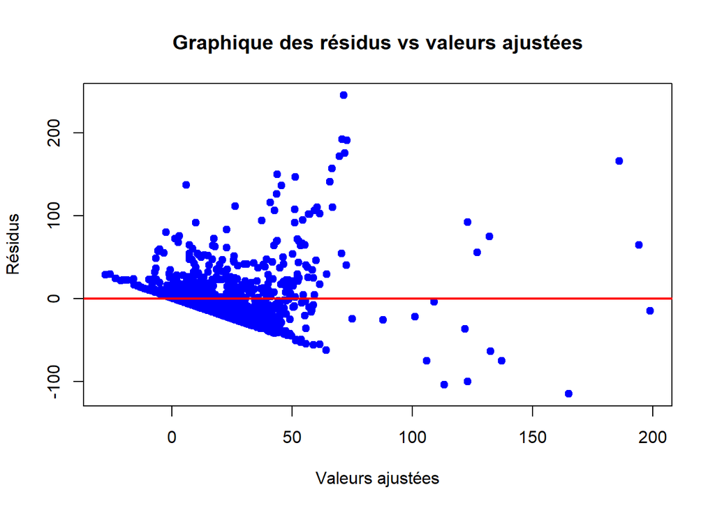

```r
plot(reg1$fitted.values, resid(reg1),
     xlab = "Valeurs ajustées",
     ylab = "Résidus",
     main = "Graphique des résidus vs valeurs ajustées",
     pch = 19, col = "blue")

# ligne horizontale à zéro
abline(h = 0, col = "red", lwd = 2)
```

## Test d’hétéroscédasticité

```
library(lmtest)
library(sandwich)
bptest(reg1)

robust_se = vcovHC(reg1, type = "HC1")
coeftest(reg1, vcov = robust_se)
```

```
##
##  studentized Breusch-Pagan test
##
## data:  reg1
## BP = 148.86, df = 5, p-value < 2.2e-16
```

```
##
## t test of coefficients:
##
##                             Estimate Std. Error t value  Pr(>|t|)
## (Intercept)                -172.8185    20.1350 -8.5830 < 2.2e-16 ***
## log_gdppc                    10.4773     1.2823  8.1710 8.764e-16 ***
## log_pop                      10.3635     1.0897  9.5102 < 2.2e-16 ***
## host                       -167.3164   202.9371 -0.8245    0.4099
## interaction_log_gdppc_host   11.0202    20.6205  0.5344    0.5932
## interaction_log_pop_host     14.1319     9.8220  1.4388    0.1505
## ---
## Signif. codes:  0 '***' 0.001 '**' 0.01 '*' 0.05 '.' 0.1 ' ' 1
```

nous avions un problème d’hétéroscédasticité, que nous avons résolu en utilisant des erreures robustes standards

## Test de multicolinéarité

```
vif(reg1)
```

```
##                  log_gdppc                    log_pop
##                   1.035223                   1.052815
##                       host interaction_log_gdppc_host
##                 145.802280                 163.112377
##   interaction_log_pop_host
##                  56.767552
```

Nous avons un problème de multicolinéarité entre les variables, que nous résolvons en les centrant

[output not shown]

[output not shown]

```
library(car)
load(".RData")
database = database %>%
  mutate(log_gdppc_centered = log_gdppc - mean(log_gdppc, na.rm = TRUE),
         log_pop_centered = log_pop - mean(log_pop, na.rm = TRUE),
         host_centered = host - mean(host, na.rm = TRUE),
         interaction_gdppc_host_centered = log_gdppc_centered * host_centered,
         interaction_pop_host_centered = log_pop_centered * host_centered)

reg_centered = lm(total_medals ~ log_gdppc_centered + log_pop_centered + host_centered + interaction_gdppc_host_centered + interaction_pop_host_centered, data = database)
summary(reg_centered)
```

```
##
## Call:
## lm(formula = total_medals ~ log_gdppc_centered + log_pop_centered +
##     host_centered + interaction_gdppc_host_centered + interaction_pop_host_centered,
##     data = database)
##
## Residuals:
##      Min       1Q   Median       3Q      Max
## -114.884  -17.862   -4.865    8.410  245.538
##
## Coefficients:
##                                 Estimate Std. Error t value Pr(>|t|)
## (Intercept)                      22.8114     0.9987  22.842  < 2e-16 ***
## log_gdppc_centered               10.6546     1.0242  10.403  < 2e-16 ***
## log_pop_centered                 10.5907     0.7024  15.077  < 2e-16 ***
## host_centered                    68.2303     7.9296   8.605  < 2e-16 ***
## interaction_gdppc_host_centered  11.0202     9.6194   1.146  0.25222
## interaction_pop_host_centered    14.1319     4.9903   2.832  0.00472 **
## ---
## Signif. codes:  0 '***' 0.001 '**' 0.01 '*' 0.05 '.' 0.1 ' ' 1
##
## Residual standard error: 32.31 on 1046 degrees of freedom
##   (689 observations effacées parce que manquantes)
## Multiple R-squared:  0.3215, Adjusted R-squared:  0.3182
## F-statistic: 99.11 on 5 and 1046 DF,  p-value: < 2.2e-16
```

## Régression avec d’autres variables

```r
load(".RData")
reg2 = lm(total_medals ~ log_gdppc_centered + log_pop_centered + host_centered + interaction_gdppc_host_centered + interaction_pop_host_centered + checks_on_gov + impartial_adm, data = database)
summary(reg2)
```

```
##
## Call:
## lm(formula = total_medals ~ log_gdppc_centered + log_pop_centered +
##     host_centered + interaction_gdppc_host_centered + interaction_pop_host_centered +
##     checks_on_gov + impartial_adm, data = database)
##
## Residuals:
##     Min      1Q  Median      3Q     Max
## -70.432 -18.931  -4.746  12.855 239.844
##
## Coefficients:
##                                  Estimate Std. Error t value Pr(>|t|)
## (Intercept)                       -3.1179     4.9874  -0.625    0.532
## log_gdppc_centered                10.4587     1.9138   5.465 6.85e-08 ***
## log_pop_centered                  13.4157     0.8871  15.124  < 2e-16 ***
## host_centered                   -167.4187    36.1866  -4.627 4.58e-06 ***
## interaction_gdppc_host_centered  171.9437    26.1506   6.575 1.07e-10 ***
## interaction_pop_host_centered     55.5156     8.4165   6.596 9.41e-11 ***
## checks_on_gov                    -40.8549    10.1580  -4.022 6.52e-05 ***
## impartial_adm                     74.7473    12.4062   6.025 2.98e-09 ***
## ---
## Signif. codes:  0 '***' 0.001 '**' 0.01 '*' 0.05 '.' 0.1 ' ' 1
##
## Residual standard error: 31.68 on 589 degrees of freedom
##   (1144 observations effacées parce que manquantes)
## Multiple R-squared:  0.4463, Adjusted R-squared:  0.4397
## F-statistic: 67.82 on 7 and 589 DF,  p-value: < 2.2e-16
```

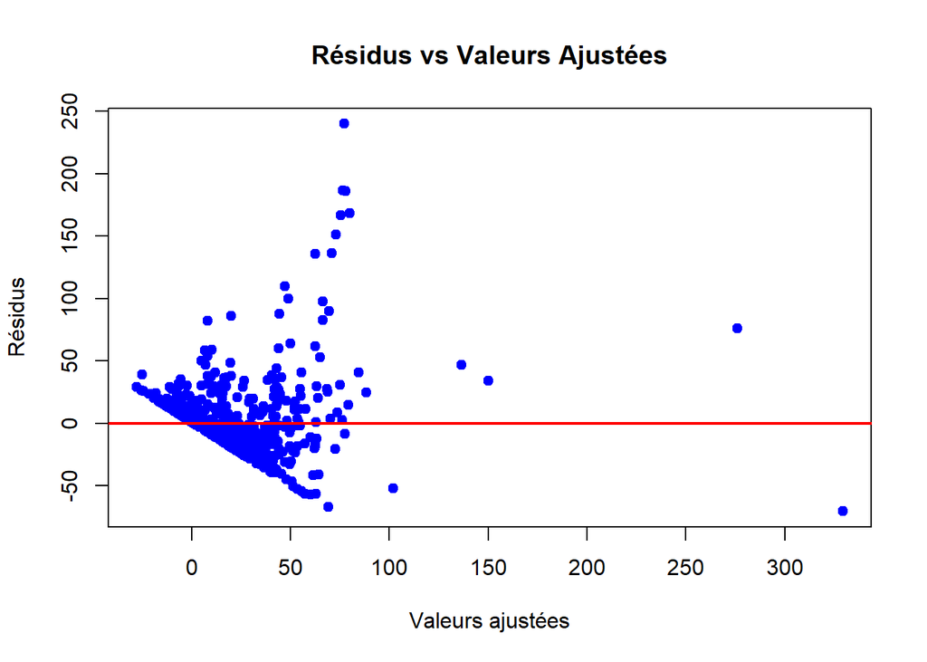

```r
# graphique des résidus par rapport aux valeurs ajustées
plot(reg2$fitted.values, resid(reg2),
     xlab = "Valeurs ajustées",
     ylab = "Résidus",
     main = "Résidus vs Valeurs Ajustées",
     pch = 19, col = "blue")

# ligne horizontale pour la référence à zéro
abline(h = 0, col = "red", lwd = 2)
```

```r
vif(reg2)
```

```
##              log_gdppc_centered                log_pop_centered
##                        2.159490                        1.085970
##                   host_centered interaction_gdppc_host_centered
##                       10.295473                        5.934302
##   interaction_pop_host_centered                   checks_on_gov
##                        3.108502                        3.084343
##                   impartial_adm
##                        4.309470
```

# Conclusion